# Assignment_9

## Assigment 9

For Assignment 9 we will explore and model the predictors of graduate school admission. First let’s start by load some packages we will use.

```r
library(tidyverse)
library(broom)
library(modelr)
library(ggplot2)
library(GGally)
```

Now let’s load our dataset.

```r
df <- read.csv("../../Data/GradSchool_Admissions.csv")
```

Now that we have the data loaded, let’s go ahead and take a look.

```r
names(df)
```

```
## [1] "admit" "gre"   "gpa"   "rank"
```

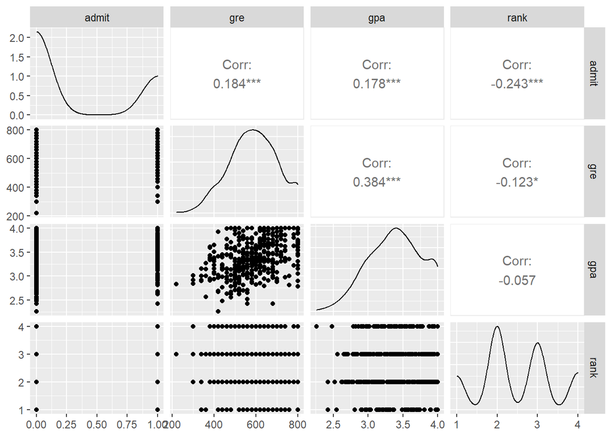

```r
ggpairs(df)
```

```r
glimpse(df)
```

```
## Rows: 400
## Columns: 4
## $ admit <int> 0, 1, 1, 1, 0, 1, 1, 0, 1, 0, 0, 0, 1, 0, 1, 0, 0, 0, 0, 1, 0...
## $ gre   <int> 380, 660, 800, 640, 520, 760, 560, 400, 540, 700, 800, 440, 7...
## $ gpa   <dbl> 3.61, 3.67, 4.00, 3.19, 2.93, 3.00, 2.98, 3.08, 3.39, 3.92, 4...
## $ rank  <int> 3, 3, 1, 4, 4, 2, 1, 2, 3, 2, 4, 1, 1, 2, 1, 3, 4, 3, 2, 1, 3...
```

As we can see, this dataset is not continuous so our graphs aren’t very helpful. Our dependent variable is the **“admit”** column, or whether a student was admitted to grad school (1) or not (0). The **“gre”** column represents each students’ GRE test score. The **“rank”** column indicates the rank of their undergraduate institution, 4 being the lowest and 1 being the highest.

In order to model our predictors of grad school admissions, we need to change the values in our “admit” column to logical values. This turns each 0 into “FALSE” and each 1 into “TRUE”. This will allow us make a logistical regression model which will be useful.

**Note: True/false predictors like the “admit” column are very useful and relevant in Biology.**

```r
df$admit <- as.logical(df$admit)
df$rank <- as.factor(df$rank)
```

Now we can begin building our models.

```r
mod1 <- glm(data = df,
            formula = admit ~ gpa * rank,
            family = "binomial")

mod2 <- glm(data = df,
            formula = admit ~ gre * rank,
            family = "binomial")

mod3 <- glm(data = df,
            formula = admit ~ gpa * rank * gre,
            family = "binomial")

mod4 <- glm(data = df,
            formula = admit ~ gpa * gre,
            family = "binomial")
```

In each model we are modeling admittance as a function of gpa, gre, rank, all, or just a few. Let’s look at a summary of each.

```r
summary(mod1)
```

```
##
## Call:
## glm(formula = admit ~ gpa * rank, family = "binomial", data = df)
##
## Deviance Residuals:
##     Min       1Q   Median       3Q      Max
## -1.5902  -0.8662  -0.6687   1.1828   2.1299
##
## Coefficients:
##             Estimate Std. Error z value Pr(>|z|)
## (Intercept)  -4.6298     2.4843  -1.864   0.0624 .
## gpa           1.3906     0.7171   1.939   0.0525 .
## rank2         0.9191     2.9618   0.310   0.7563
## rank3         0.1892     3.2431   0.058   0.9535
## rank4        -1.1121     4.1319  -0.269   0.7878
## gpa:rank2    -0.4661     0.8584  -0.543   0.5871
## gpa:rank3    -0.4567     0.9295  -0.491   0.6232
## gpa:rank4    -0.1378     1.1999  -0.115   0.9085
## ---
## Signif. codes:  0 '***' 0.001 '**' 0.01 '*' 0.05 '.' 0.1 ' ' 1
##
## (Dispersion parameter for binomial family taken to be 1)
##
##     Null deviance: 499.98  on 399  degrees of freedom
## Residual deviance: 462.49  on 392  degrees of freedom
## AIC: 478.49
##
## Number of Fisher Scoring iterations: 4
```

```r
summary(mod2)
```

```
##
## Call:
## glm(formula = admit ~ gre * rank, family = "binomial", data = df)
##
## Deviance Residuals:
##     Min       1Q   Median       3Q      Max
## -1.5794  -0.9048  -0.6431   1.2242   2.0970
##
## Coefficients:
##               Estimate Std. Error z value Pr(>|z|)
## (Intercept) -2.220e+00  1.413e+00  -1.571   0.1161
## gre          3.910e-03  2.284e-03   1.712   0.0869 .
## rank2        2.175e-01  1.731e+00   0.126   0.9000
## rank3       -1.337e+00  1.855e+00  -0.721   0.4711
## rank4       -1.082e+00  2.210e+00  -0.490   0.6243
## gre:rank2   -1.549e-03  2.807e-03  -0.552   0.5811
## gre:rank3    8.246e-05  3.006e-03   0.027   0.9781
## gre:rank4   -8.584e-04  3.614e-03  -0.238   0.8123
## ---
## Signif. codes:  0 '***' 0.001 '**' 0.01 '*' 0.05 '.' 0.1 ' ' 1
##
## (Dispersion parameter for binomial family taken to be 1)
##
##     Null deviance: 499.98  on 399  degrees of freedom
## Residual deviance: 464.00  on 392  degrees of freedom
## AIC: 480
##
## Number of Fisher Scoring iterations: 4
```

```r
summary(mod3)
```

```
##
## Call:
## glm(formula = admit ~ gpa * rank * gre, family = "binomial",
##     data = df)
##
## Deviance Residuals:
##     Min       1Q   Median       3Q      Max
## -1.7664  -0.8518  -0.6437   1.0565   2.2283
##
## Coefficients:
##                 Estimate Std. Error z value Pr(>|z|)
## (Intercept)   -35.999967  16.048971  -2.243   0.0249 *
## gpa            10.242737   4.716620   2.172   0.0299 *
## rank2          33.954685  18.430800   1.842   0.0654 .
## rank3          14.608867  20.838126   0.701   0.4833
## rank4          13.935601  24.587935   0.567   0.5709
## gre             0.052274   0.025176   2.076   0.0379 *
## gpa:rank2     -10.105436   5.447632  -1.855   0.0636 .
## gpa:rank3      -4.978875   6.062873  -0.821   0.4115
## gpa:rank4      -4.666198   7.120462  -0.655   0.5123
## gpa:gre        -0.014640   0.007294  -2.007   0.0447 *
## rank2:gre      -0.054299   0.029213  -1.859   0.0631 .
## rank3:gre      -0.020111   0.033741  -0.596   0.5511
## rank4:gre      -0.023092   0.040135  -0.575   0.5651
## gpa:rank2:gre   0.015725   0.008524   1.845   0.0651 .
## gpa:rank3:gre   0.006381   0.009675   0.659   0.5096
## gpa:rank4:gre   0.006888   0.011536   0.597   0.5505
## ---
## Signif. codes:  0 '***' 0.001 '**' 0.01 '*' 0.05 '.' 0.1 ' ' 1
##
## (Dispersion parameter for binomial family taken to be 1)
##
##     Null deviance: 499.98  on 399  degrees of freedom
## Residual deviance: 450.39  on 384  degrees of freedom
## AIC: 482.39
##
## Number of Fisher Scoring iterations: 5
```

```r
summary(mod4)
```

```
##
## Call:
## glm(formula = admit ~ gpa * gre, family = "binomial", data = df)
##
## Deviance Residuals:
##     Min       1Q   Median       3Q      Max
## -1.1324  -0.9387  -0.7099   1.2969   2.3519
##
## Coefficients:
##               Estimate Std. Error z value Pr(>|z|)
## (Intercept) -13.818700   5.874816  -2.352   0.0187 *
## gpa           3.367918   1.722685   1.955   0.0506 .
## gre           0.017464   0.009606   1.818   0.0691 .
## gpa:gre      -0.004327   0.002787  -1.552   0.1205
## ---
## Signif. codes:  0 '***' 0.001 '**' 0.01 '*' 0.05 '.' 0.1 ' ' 1
##
## (Dispersion parameter for binomial family taken to be 1)
##
##     Null deviance: 499.98  on 399  degrees of freedom
## Residual deviance: 477.85  on 396  degrees of freedom
## AIC: 485.85
##
## Number of Fisher Scoring iterations: 4
```

These summaries aren’t giving very significant indicators of admittance so before we test our predictions we’re going to narrow down the model selection by comparing our residuals.

```r
abs(residuals(mod1)) %>% mean
```

```
## [1] 1.007515
```

```r
abs(residuals(mod2)) %>% mean
```

```
## [1] 1.010515
```

```r
abs(residuals(mod3)) %>% mean
```

```
## [1] 0.9845051
```

```r
abs(residuals(mod4)) %>% mean
```

```
## [1] 1.035365
```

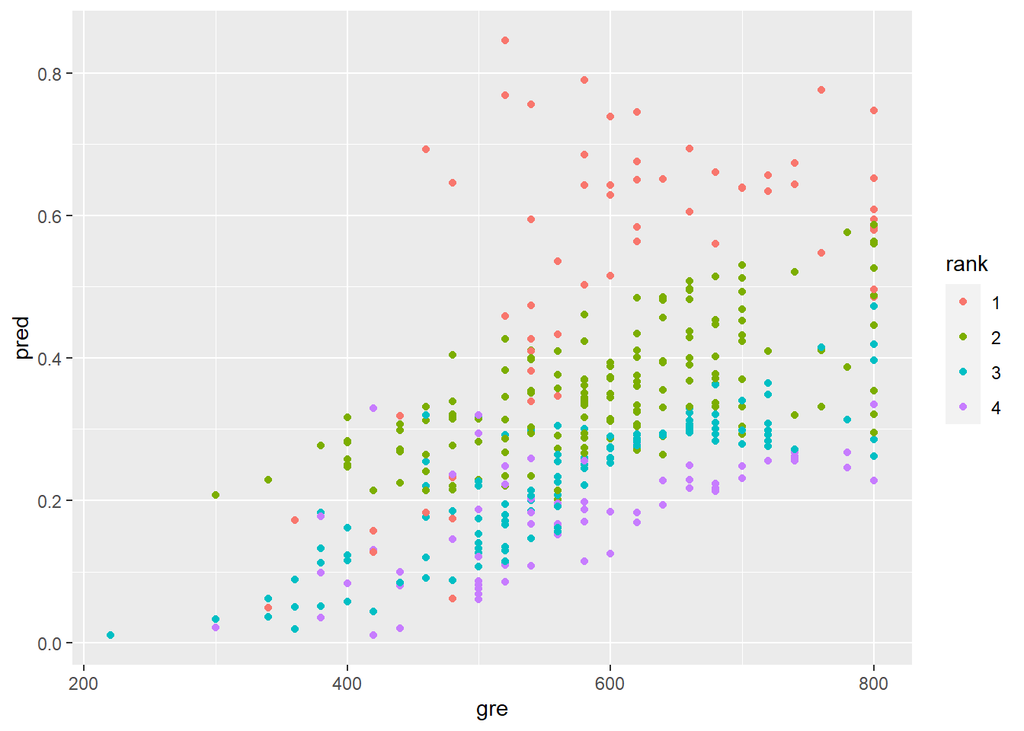

```r
add_predictions(df, mod3, type = "response") %>%
  ggplot() +
  geom_point(aes(x=gre, y=pred, color = rank))
```

### What does this mean?

This graph shows that as a student’s GRE score increases, so does their chances of getting into grad school. The color by rank shows that students that attended Rank 1 schools are even more likely to get in than other ranks at a certain point. Let’s look at another graph.

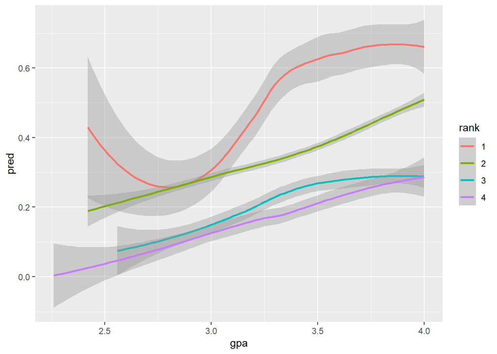

```r
add_predictions(df, mod3, type = "response") %>%
  ggplot(aes(x=gpa, y=pred, color = rank)) +
  geom_smooth()
```

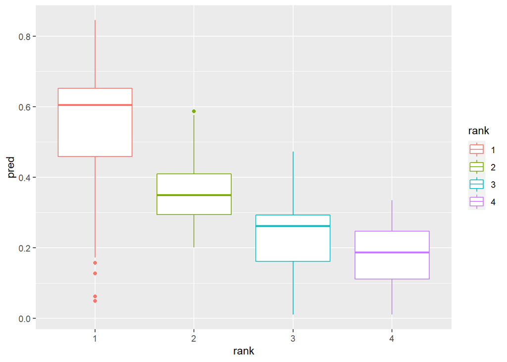

```r
add_predictions(df, mod3, type = "response") %>%
  ggplot() +
  geom_boxplot(aes(x=rank, y=pred, color = rank))
```

This boxplot further demonstrates the trends already shown. Students with a higher rank have a better chance of getting into graduate school. The graphs have shown some outliers in the predictions. These could be explained by data that we do not possess, or simply be because of immeasurable factors.